# Review from last time

- When there is non-zero correlation of the error (or non-constant variance), in certain cases we can successfully reduce this back to our normal regression framework with generalized least squares.
- Particularly, let's assume that the error takes a particular (but more general) form,

  \[ \begin{align} cov\left(\boldsymbol{\epsilon}\right) = \sigma^2 \boldsymbol{\Sigma} \end{align} \]

  for a *known structure matrix* for the error \( \boldsymbol{\Sigma} \) but perhaps an *unkown scale coefficient* \( \sigma^2 \).
- This describes a sittuation in which we have knowledge of the correlation and relative variance between the errors, but we don't know the absolute scale of the variation.
- We will write \( \boldsymbol{\Sigma} = \mathbf{S} \mathbf{S}^\mathrm{T} \) in a Cholesky decomposition.
- Then, considering our form for the signal

  \[ \begin{align} \mathbf{Y}& = \mathbf{X} \boldsymbol{\beta} + \boldsymbol{\epsilon}&\\ \Leftrightarrow \mathbf{S}^{-1} \mathbf{Y}& = \mathbf{S}^{-1}\mathbf{X} \boldsymbol{\beta} + \mathbf{S}^{-1}\boldsymbol{\epsilon}\\ \Leftrightarrow \mathbf{Y}' &= \mathbf{X}' \boldsymbol{\beta} + \boldsymbol{\epsilon}' \end{align} \]
- Supposing that we can compute the variables,

  \[ \begin{align} \mathbf{X}' &\triangleq \mathbf{S}^{-1} \mathbf{X} \\ \mathbf{Y}' &\triangleq \mathbf{S}^{-1} \mathbf{Y} \end{align} \]

  the regression of \( \mathbf{Y}' \) in terms of \( \mathbf{X}' \) satisfies our usual Gauss-Markov assumptions, for error \( \boldsymbol{\epsilon}' \) such that \( cov\left(\boldsymbol{\epsilon}\right) = \sigma^2 \mathbf{I} \).
- Because the assumptions of the Gauss-Markov theorem hold for the transformed variables, we can re-derive the least-squares solution minimizing the associated residual sum of squares error.

## Weighted least squares

- As a special case of generalized least squares, we can consider the case when the errors are uncorrelated, but have unequal variances.
- That is to say, \( cov\left(\boldsymbol{\epsilon}\right) = \boldsymbol{\Sigma} \) where,

  \[ \boldsymbol{\Sigma} = \begin{pmatrix} 1/w_1& 0 & \cdots & 0 \\ 0 & 1/w_2 & \cdots & \vdots \\ \vdots & \ddots & \ddots & \vdots \\ 0 & 0 & \cdots & 1/w_n \end{pmatrix} \] for possibly \( w_i \neq w_j \), but \( \boldsymbol{\Sigma} \) is strictly diagonal.
- Here, we will refer to the reciprocals of the individual variances, \( w_i \), as the **weights**.
- As a special case of generalized least squares, we can compute the transformation into the variables \( \mathbf{X}', \mathbf{Y}', \boldsymbol{\epsilon}' \) as

  \[ \begin{align} \mathbf{X}' &\triangleq \mathbf{S}^{-1} \mathbf{X} = \mathrm{diag}\left(\sqrt{w_i} \right)\mathbf{X}, \\ \mathbf{Y}' & \triangleq \mathbf{S}^{-1} \mathbf{Y} = \mathrm{diag}\left(\sqrt{w_i} \right) \mathbf{Y}, \\ \boldsymbol{\epsilon}' & \triangleq \mathbf{S}^{-1} \boldsymbol{\epsilon} = \mathrm{diag}\left(\sqrt{w_i} \right)\boldsymbol{\epsilon}; \end{align} \]
  - By direct matrix computation, we see that the **\( i \)-th row** of the matrix \( \mathbf{X} \) is scaled by the inverse of the standard deviation of the \( i \)-th observation.
- We note, the column corresponding to the intercept term in the matrix \( \mathbf{X} \) will be a vector of the form,

  \[ \begin{align} \begin{pmatrix} \sqrt{w_1}, &\cdots, & \sqrt{w_n}\end{pmatrix}^\mathrm{T}, \end{align} \] instead of the usual vector of ones.
- Qualitatively, we can note that
  1. the observations of high variance

     \[ \begin{align} \frac{1}{\sqrt{w_i}} \gg 1 \end{align} \]

     will recieve low weight in the regression \( \sqrt{w_i} \ll 1 \), while
  2. the observations of low variance

     \[ \begin{align} \frac{1}{\sqrt{w_i}} \ll 1 \end{align} \]

     will recieve high weight in the regression \( \sqrt{w_i} \gg 1 \)

## Testing for lack of fit

- When our assumptions (e.g., G-M) hold then the residual standard error,

  \[ \begin{align} \hat{\sigma}^2 \triangleq \frac{\hat{\epsilon}^\mathrm{T} \hat{\epsilon}}{n-p} \end{align} \]

  is an unbiased estimate of the true variance \( \sigma^2 \) of the error.
- However, we have now seen many ways how these assumptions can break down.
  - When the model doesn't have the appropriate structure or is not complex enough to fit the data, we will typically overestimate \( \sigma^2 \) with the emprical \( \hat{\sigma}^2 \);
  - likewise, if we over parameterize the model, then \( \hat{\sigma}^2 \) will typically underestimate the true variance \( \sigma^2 \).
- In an ideal sittuation, where we may actually know \( \sigma^2 \), comparing the two values would lead us to understanding the fit of the model by our empirical estimate versus the known value.
  - One example may be when we have only measurement errors for the observations with known variance in their measurments.
- By the same principle, we may more generally get a good estimate of \( \sigma^2 \) when we have multiple observations of the response for the same values of the explanatory variables.
- We note that this requires an assumption of the **independence** of the measurements.
  - That is to say, we need to require that we have multiple independent observations corresponding to the same value of the explanatory variable.
- For example, we may be measuring blood presssure as the response variable and using age, height, weight, and other measurements as the explanatory varibles in a model.
- It won't suffice to re-measure the same individual to obtain an estimate of \( \sigma^2 \) as this will only measure the within-subjet variability.
- Rather, we would need to find multiple individuals with the same measurements for the explanatory varibles to estimate the variance \( \sigma^2 \) of the error around the signal.
- We call these multiple, independent observations of the response, with the identical explanatory variables **replicates**.
- Let \( \mathbf{Y}_{ij} \) be the \( i \)-th observation of the \( j \)-th group of replicates.
  - This is to say that all \( \mathbf{Y}_{ij} \) correspond to the same values of \( \mathbf{x}_j \) where \( \mathbf{x}_j \) will be a set of measurements of the explanatory variables.
- We can then estimate \( \sigma^2 \) independently of the regression model as

  \[ \begin{align} \frac{SS_{pe}}{df_{pe}} \triangleq& \frac{\sum_{j}\sum_{i}\left(\mathbf{Y}_{ij} - \overline{\mathbf{Y}}_{j}\right)^2}{\sum_j \left( \text{number of replicates of type }j - 1\right)} \\ &=\frac{\sum_{j}\sum_{i}\left(\mathbf{Y}_{ij} - \overline{\mathbf{Y}}_{j}\right)^2}{n - \text{number of groups}} \end{align} \]
- The estimate given above is known as the **pure error**.
- We can formulate a test for lack of fit in terms of the ratio of the two estimates for variance, i.e.,
  1. the estimate by the pure error above;
  2. and the regression based estimate of \( \hat{\sigma}^2 \).

**Q:** what test statistic can we use to test if two empirical variances match?

**A:** this can be done with the F-test.

- A convenient way to perform the last F-test is as follows:
1. We may fit a model in which each value for a replicate group is treated as a factor;
2. by treating these as a categorical factor, our model becomes saturated as there will be one parameter in the model per replicate group;
3. the fitted value for each group of replicates will be given as the mean for this group of replicates;
4. while this doesn't provide a model for explaining the phenomenon, the standard error of this dummy model is equal to the pure error;
5. thus, we can use the F-test in an ANOVA table to compare the regression model standard error with the pure error.
- We will demonstrate this process in an example.

### An example of testing for lack of fit

- We can perform a lack of fit test with the corrosion data in the Faraway package, studying the loss of weight in samples of copper/ nickel alloy, due to corrosion, when placed in sea water.

```r
library("faraway")
head(corrosion)
```

```
    Fe  loss
1 0.01 127.6
2 0.48 124.0
3 0.71 110.8
4 0.95 103.9
5 1.19 101.5
6 0.01 130.1
```

- Each sample has varying ammounts of iron, and the loss is measured in terms of milligrams per day.
- We fit a simple regression model for the rate of loss per day based on the iron content:

```r
lmod <- lm(loss ~ Fe, corrosion)
sumary(lmod)
```

```
            Estimate Std. Error t value  Pr(>|t|)
(Intercept) 129.7866     1.4027  92.524 < 2.2e-16
Fe          -24.0199     1.2798 -18.769 1.055e-09

n = 13, p = 2, Residual SE = 3.05778, R-Squared = 0.97
```

- We plot the simple regression along with the data points:

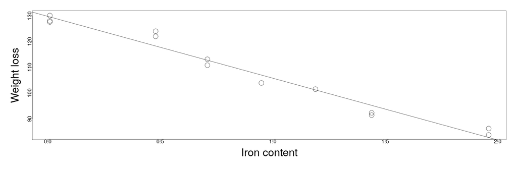

```r
par(mai=c(1.5,1.5,.5,.5), mgp=c(3,0,0))
plot(loss ~ Fe, corrosion,xlab="Iron content",ylab="Weight loss",  cex=3, cex.lab=3, cex.axis=1.5)
abline(coef(lmod))
```

- although the \( R^2 \) value is strong, and the fit looks “OK” we want to test this intuition more formally.
- Here, in the ANOVA table, the null hypothesis is that the standard error estimate and the pure error estimate are empirical variances that approximate the same \( \sigma^2 \).
- The alternative hypothesis is that these do not estimate the same quantity, i.e., that the regression model lacks fit.
  - In particular, this would say that the form of the model,

  $$\begin{align} \mathbf{Y} = \mathbf{X} \boldsymbol{\beta} + \boldsymbol{\epsilon} \end{align}$$

  is not an accurate form for the model, as the pure error doesn't match the error given by this formulation.

```r
lmoda <- lm(loss ~ factor(Fe), corrosion)
anova(lmod, lmoda)
```

```
Analysis of Variance Table

Model 1: loss ~ Fe
Model 2: loss ~ factor(Fe)
  Res.Df     RSS Df Sum of Sq      F   Pr(>F)
1     11 102.850
2      6  11.782  5    91.069 9.2756 0.008623 **
---
Signif. codes:  0 '***' 0.001 '**' 0.01 '*' 0.05 '.' 0.1 ' ' 1
```

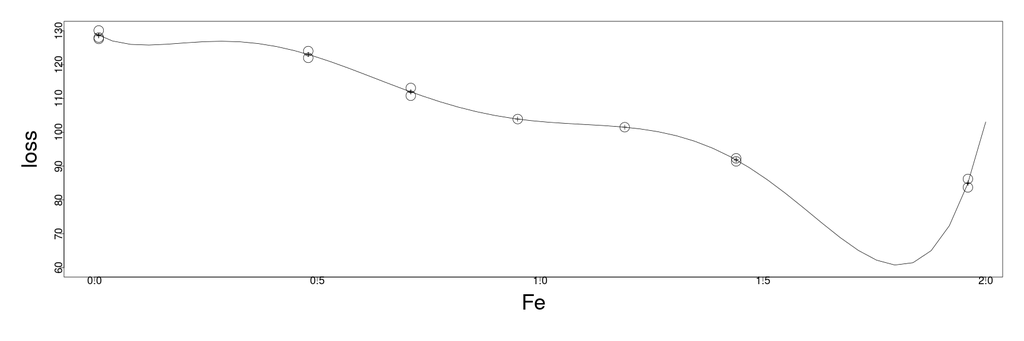

[figure not shown]

```r
par(mai=c(1.5,1.5,.5,.5), mgp=c(3,0,0))
lmodp <- lm(loss ~ Fe+I(Fe^2)+I(Fe^3)+I(Fe^4)+I(Fe^5)+I(Fe^6),corrosion)
plot(loss ~ Fe, data=corrosion,ylim=c(60,130), cex=3, cex.lab=3, cex.axis=1.5)
points(corrosion$Fe,fitted(lmoda),pch=3)
grid <- seq(0,2,len=50)
lines(grid,predict(lmodp, data.frame(Fe=grid)))
```

- In the previous example, including higher order terms increased the \( R^2 \) value significantly, but became a case of obvious over-fitting.
- In general, we cannot fixate too much on \( R^2 \) for this reason, but we must be aware of the structure of the data and the model.
- In a different example, to the left, it is natural to use quadratic terms in the explanatory variable, rather than linear;
- a model that is linear in the explanatory variable, versus quadratic, will overestimate \( \sigma^2 \) via \( \hat{\sigma}^2 \), but the model that is quadratic in \( x \) will be unbiased.
- Starting next time, we will start discussing transformations of the variables and model selection…